# SMART-Seq2 mRNA-Seq of 96 2cell embryos injected and nonInjected w active/dead-Btgh - embryo filtering and clustering

Sara Formichetti

EMBL Rome  
sara.formichetti@embl.it

February 18th, 2022

# 1 Design of the experiment

| sample | SRR | condition | group_or_time_point | batch | biol_rep | tech_rep | run | library_layout | read_length | perc_rDNA |
| --- | --- | --- | --- | --- | --- | --- | --- | --- | --- | --- |
| A1 | none | active_Btgh | 1 | 1 | 1 | 1 | 1 | PAIRED - | 40 | 14.74 |
| A10 | none | active_Btgh | 1 | 1 | 10 | 1 | 1 | PAIRED - | 40 | 16.56 |
| A2 | none | active_Btgh | 1 | 1 | 2 | 1 | 1 | PAIRED - | 40 | 13.51 |
| A24 | none | active_Btgh | 1 | 1 | 11 | 1 | 1 | PAIRED - | 40 | 17.31 |
| A25 | none | active_Btgh | 1 | 1 | 12 | 1 | 1 | PAIRED - | 40 | 16.53 |
| A26 | none | active_Btgh | 1 | 1 | 13 | 1 | 1 | PAIRED - | 40 | 15.38 |
| A28 | none | active_Btgh | 1 | 1 | 15 | 1 | 1 | PAIRED - | 40 | 15.13 |
| A29 | none | active_Btgh | 1 | 1 | 16 | 1 | 1 | PAIRED - | 40 | 14.26 |
| A3 | none | active_Btgh | 1 | 1 | 3 | 1 | 1 | PAIRED - | 40 | 13.99 |
| A31 | none | active_Btgh | 1 | 2 | 17 | 1 | 1 | PAIRED - | 40 | 9.68 |
| A32 | none | active_Btgh | 1 | 2 | 18 | 1 | 1 | PAIRED - | 40 | 18.56 |
| A33 | none | active_Btgh | 1 | 2 | 19 | 1 | 1 | PAIRED - | 40 | 12.77 |
| A34 | none | active_Btgh | 1 | 2 | 20 | 1 | 1 | PAIRED - | 40 | 20.38 |
| A35 | none | active_Btgh | 1 | 2 | 21 | 1 | 1 | PAIRED - | 40 | 16.19 |
| A36 | none | active_Btgh | 1 | 2 | 22 | 1 | 1 | PAIRED - | 40 | 15.79 |
| A37 | none | active_Btgh | 1 | 2 | 23 | 1 | 1 | PAIRED - | 40 | 14.54 |
| A39 | none | active_Btgh | 1 | 2 | 25 | 1 | 1 | PAIRED - | 40 | 11.35 |
| A4 | none | active_Btgh | 1 | 1 | 4 | 1 | 1 | PAIRED - | 40 | 14.87 |
| A40 | none | active_Btgh | 1 | 2 | 26 | 1 | 1 | PAIRED - | 40 | 15.56 |
| A5 | none | active_Btgh | 1 | 1 | 5 | 1 | 1 | PAIRED - | 40 | 13.87 |
| A52 | none | active_Btgh | 1 | 2 | 27 | 1 | 1 | PAIRED - | 40 | 14.62 |
| A53 | none | active_Btgh | 1 | 2 | 28 | 1 | 1 | PAIRED - | 40 | 17.16 |
| A54 | none | active_Btgh | 1 | 2 | 29 | 1 | 1 | PAIRED - | 40 | 15.38 |
| A55 | none | active_Btgh | 1 | 2 | 30 | 1 | 1 | PAIRED - | 40 | 16.05 |
| A57 | none | active_Btgh | 1 | 2 | 32 | 1 | 1 | PAIRED - | 40 | 14.24 |
| A6 | none | active_Btgh | 1 | 1 | 6 | 1 | 1 | PAIRED - | 40 | 18.09 |
| A7 | none | active_Btgh | 1 | 1 | 7 | 1 | 1 | PAIRED - | 40 | 18.02 |
| A8 | none | active_Btgh | 1 | 1 | 8 | 1 | 1 | PAIRED - | 40 | 15.50 |
| A9 | none | active_Btgh | 1 | 1 | 9 | 1 | 1 | PAIRED - | 40 | 18.90 |
| C1 | none | non_injected | 1 | 1 | 1 | 1 | 1 | PAIRED - | 40 | 13.76 |

[output cut: 58 more lines]

# 2 Quality filtering of embryos

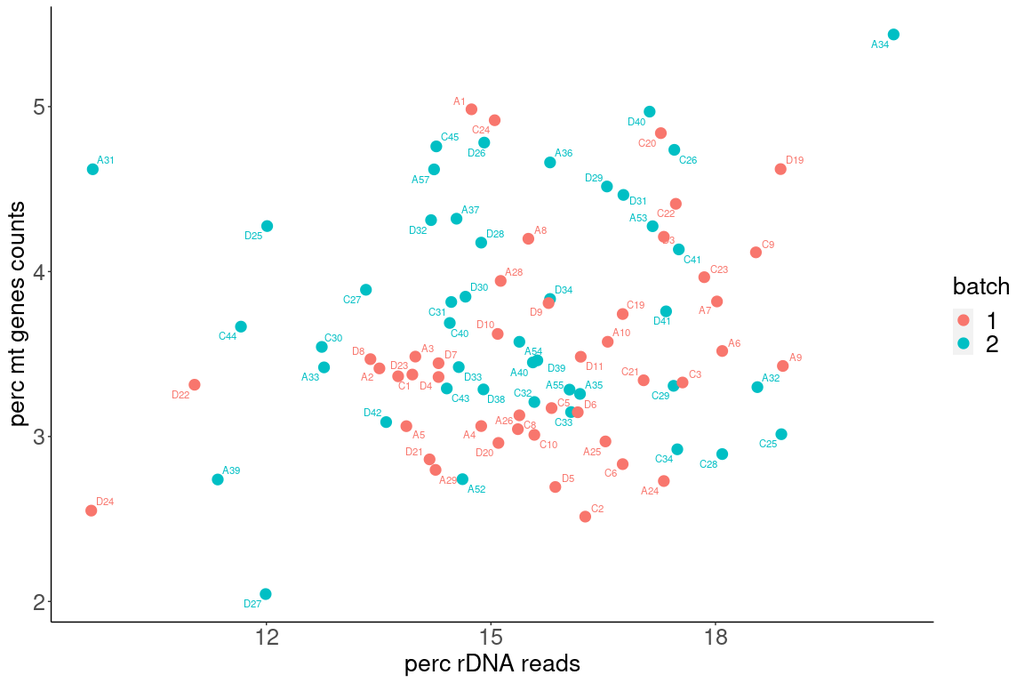

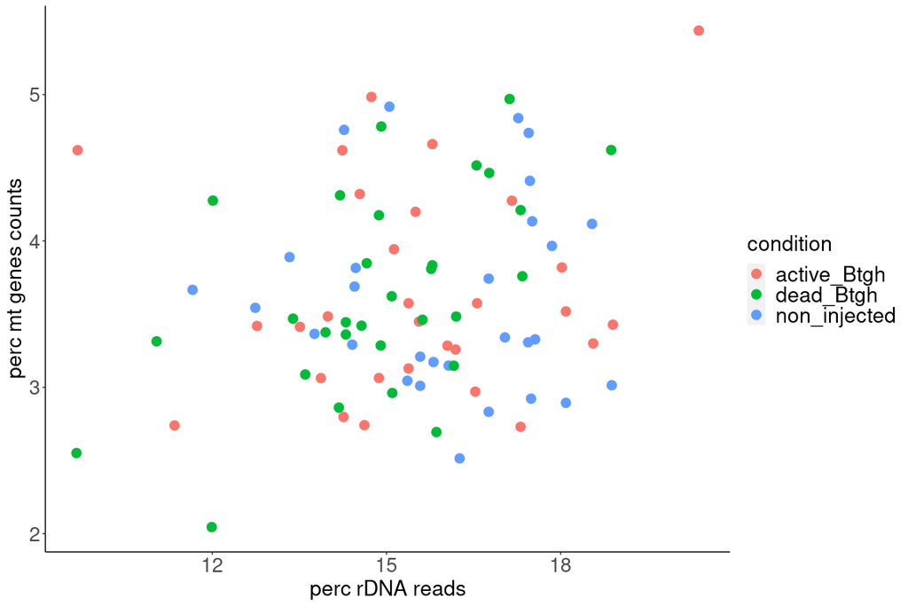

Based on the above plot, I only exclude sample A34 from the analysis.

# 3 Counts of Btgh RNA molecules

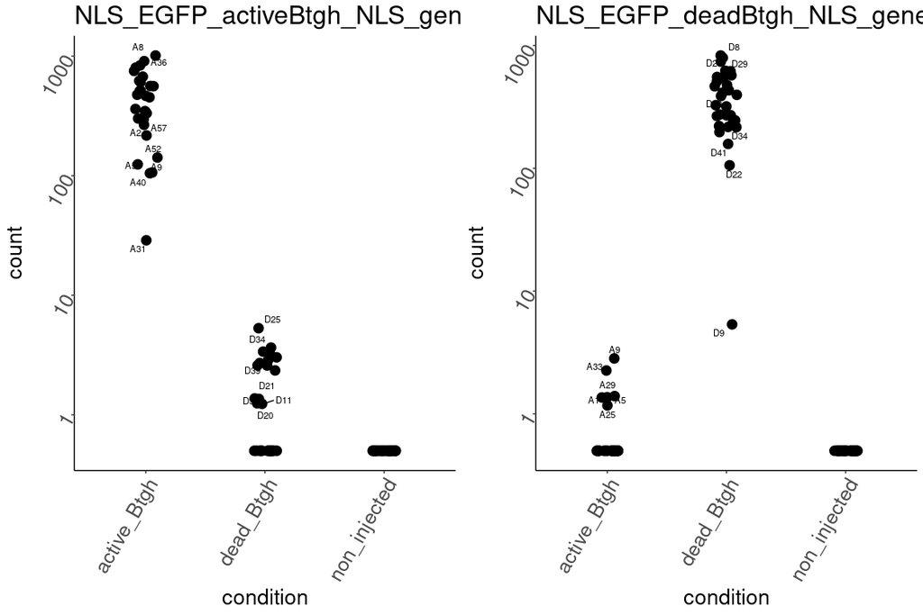

Based on the plots above, I exclude sample D9 and A31 because poorly injected. From now on, I also remove Btgh from the counts table.

# 4 Sample clustering

## 4.1 Heatmap for quality assessment

After applying the log2(n + 1) transformation, I plot heatmaps of normalized counts for top highly expressed genes to check for eventual big sample heterogeneity present in the dataset.

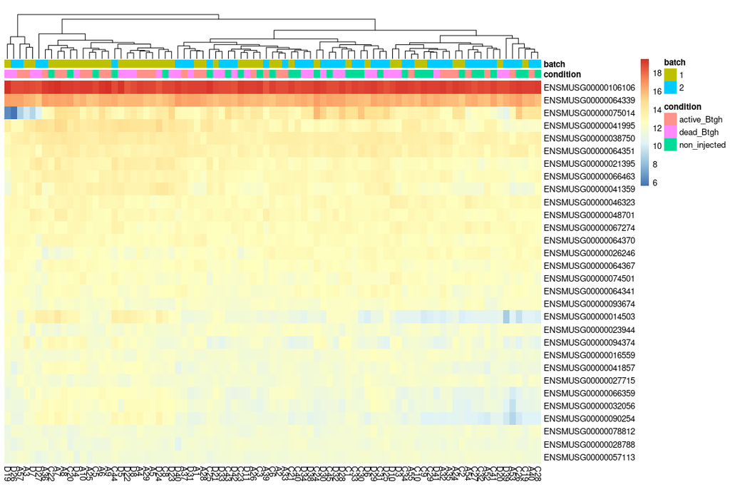

The main sample heterogeneity present in the data is between batches. Batch2 tends to have less counts for some genes.

## 4.2 PCA

For this PCA:

1. I start with DESeq2-normalized data
2. I keep only genes with DESeq2-normalized mean across samples > 10
3. I apply log2 transformation
4. I perform PCA with package prcomp using the 1000 genes with the highest variance

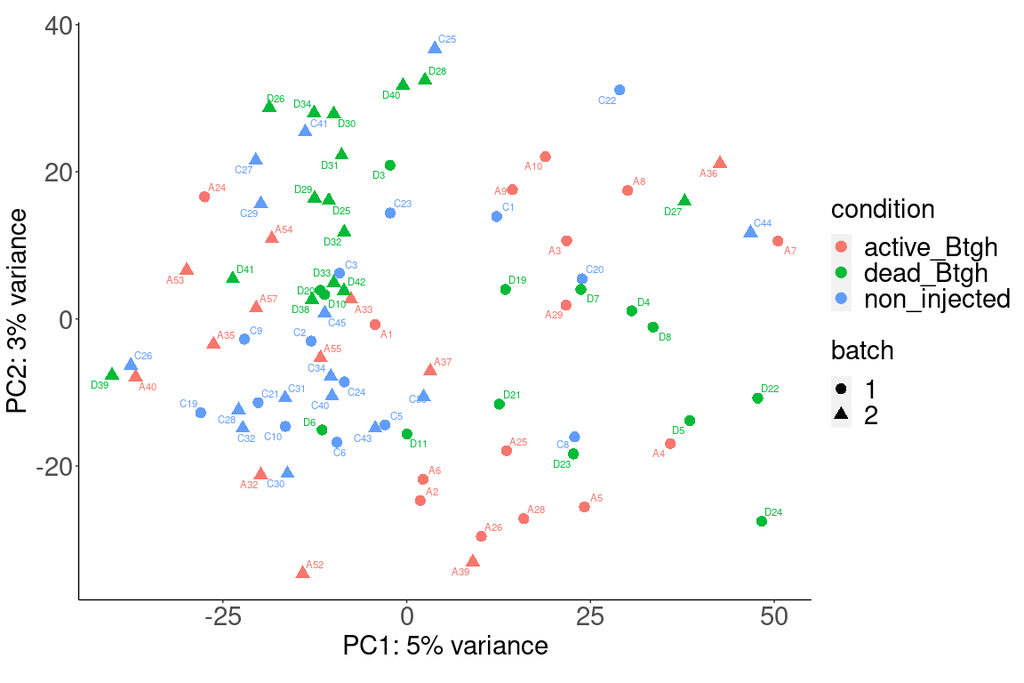

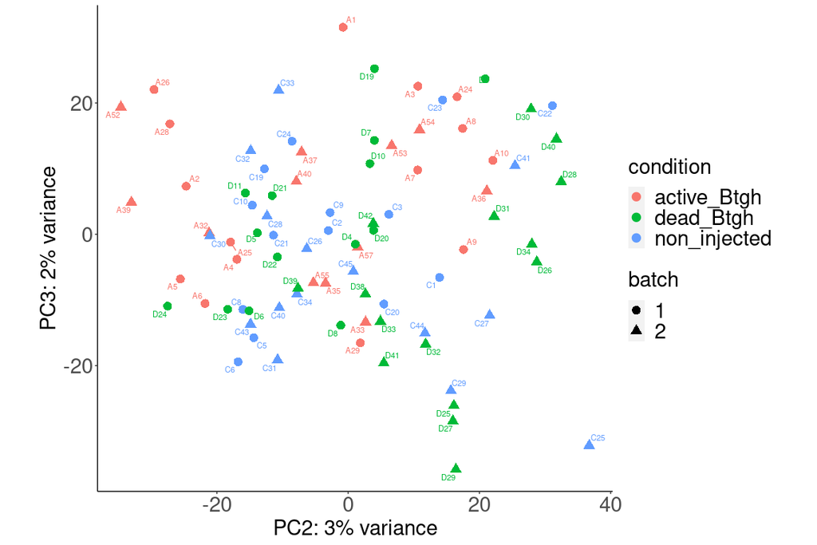

Two main conclusions:

- **Unwanted variation correlated with batch** is visible, especially for the injected samples.
- No clusters correlating with condition.

I will try to remove the unwanted variation using package function **RUVs** of package **RUVSeq**.

## 4.3 Removing batch effect and other counfounding factors with RUVs

I use RUVs, which exploits the info of a known grouping of samples to find the factors of unwanted variation. In my case, the known groups are the three conditions.

### 4.3.1 Examining RUVs effect via PCA and RLE plots

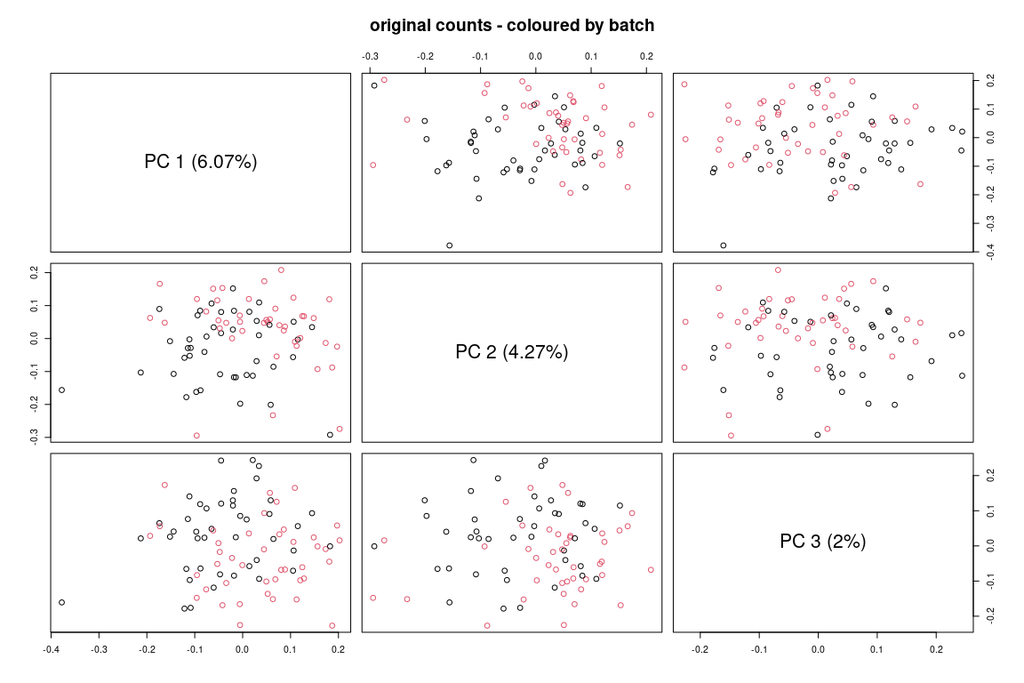

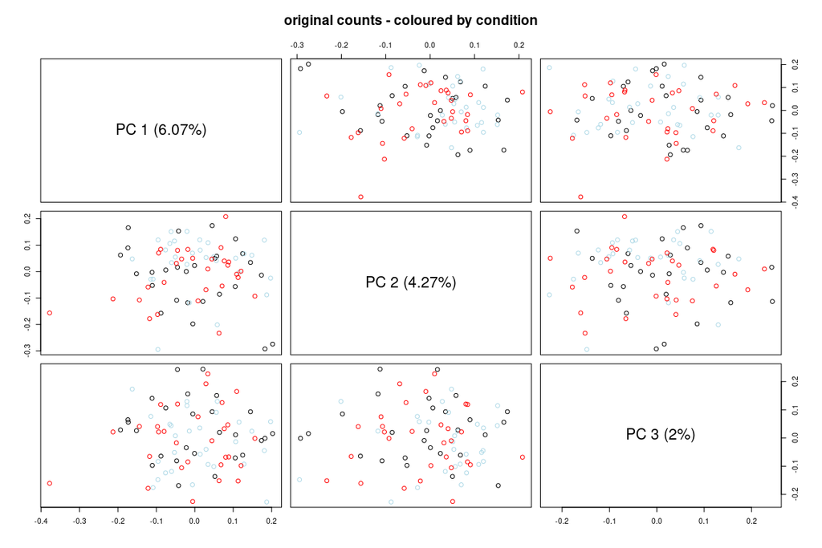

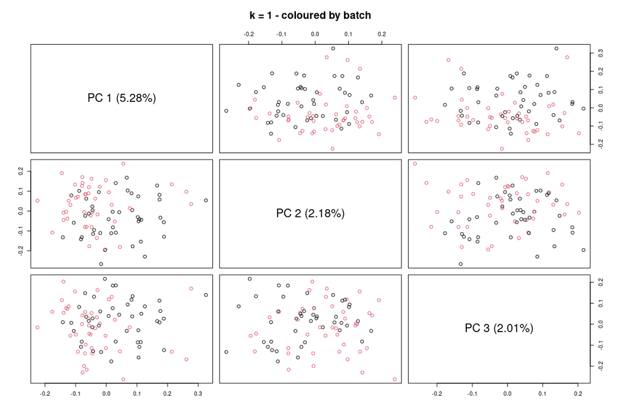

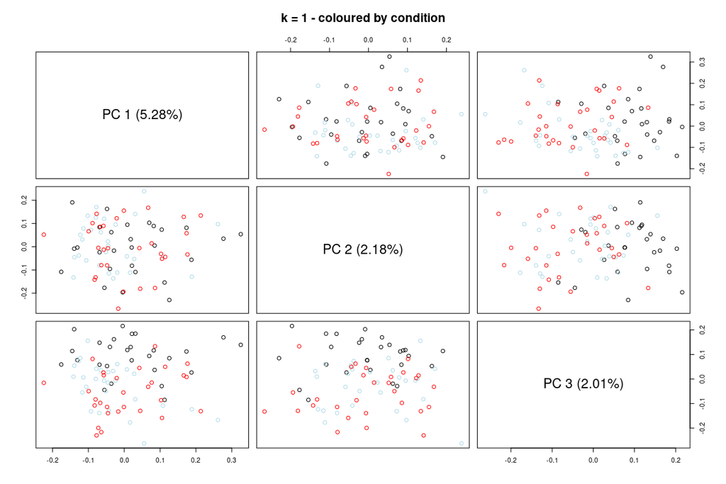

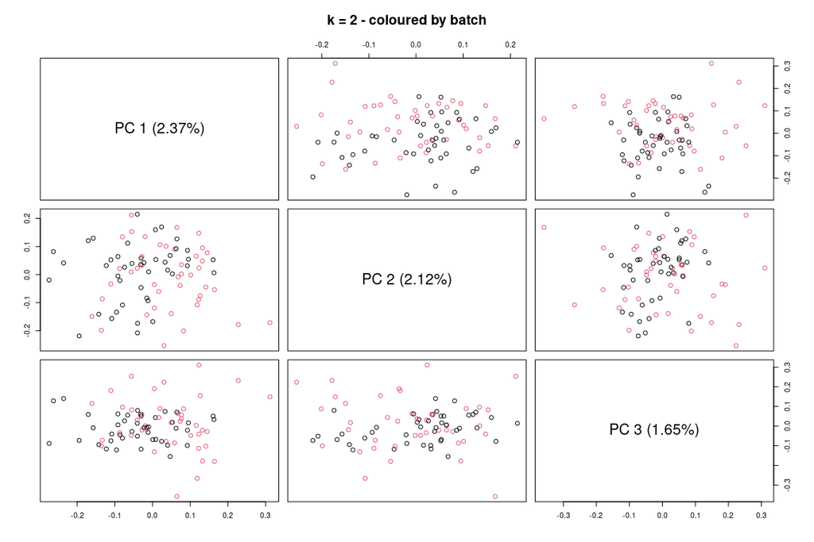

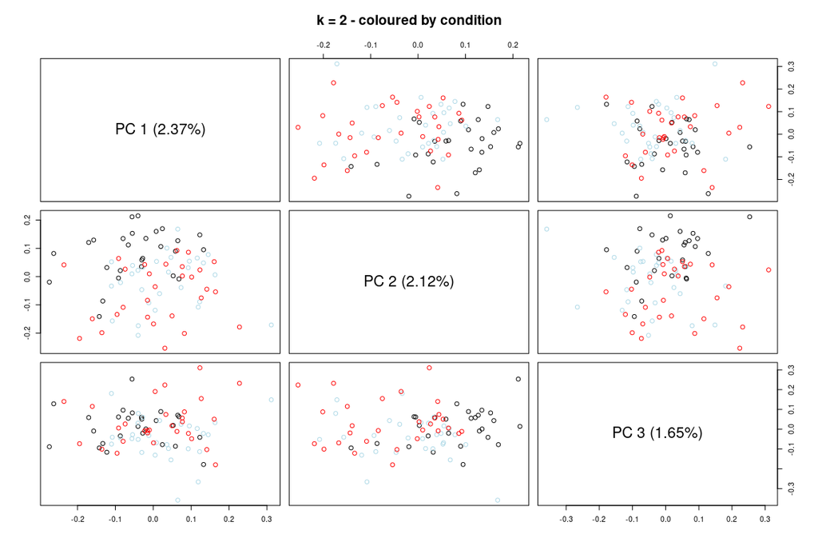

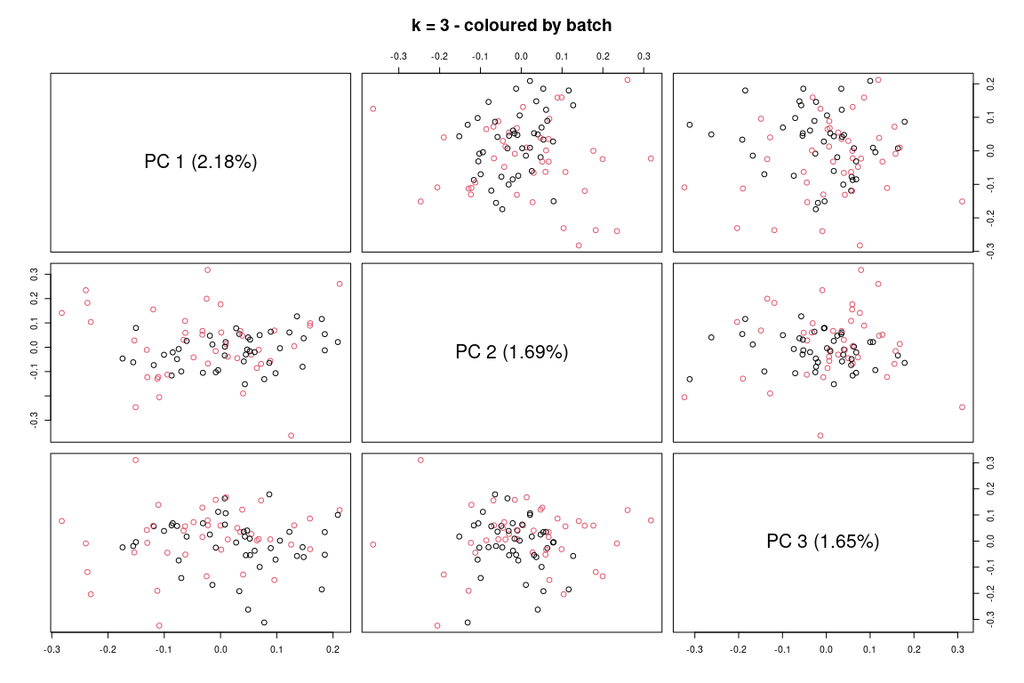

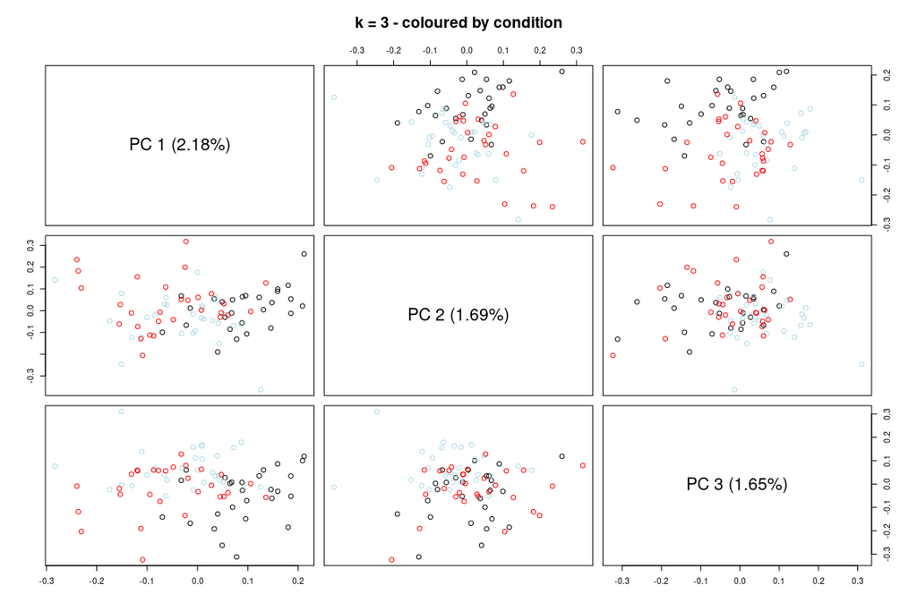

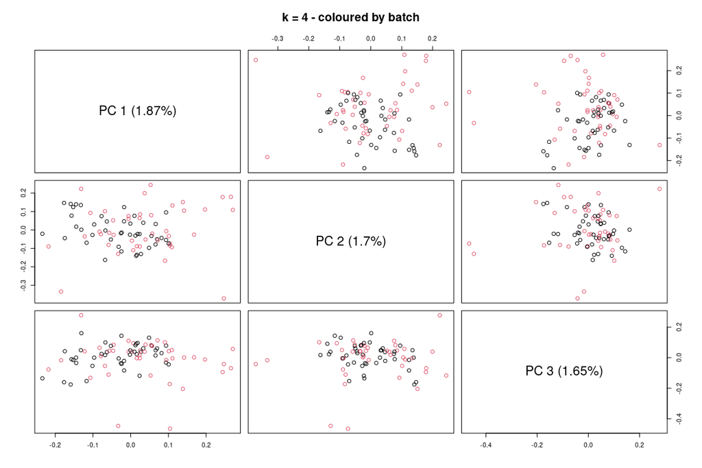

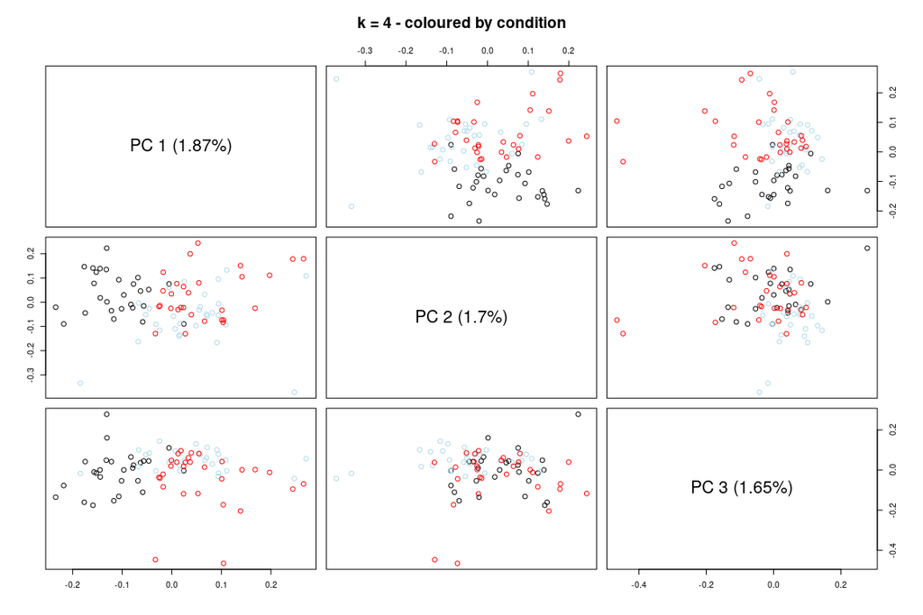

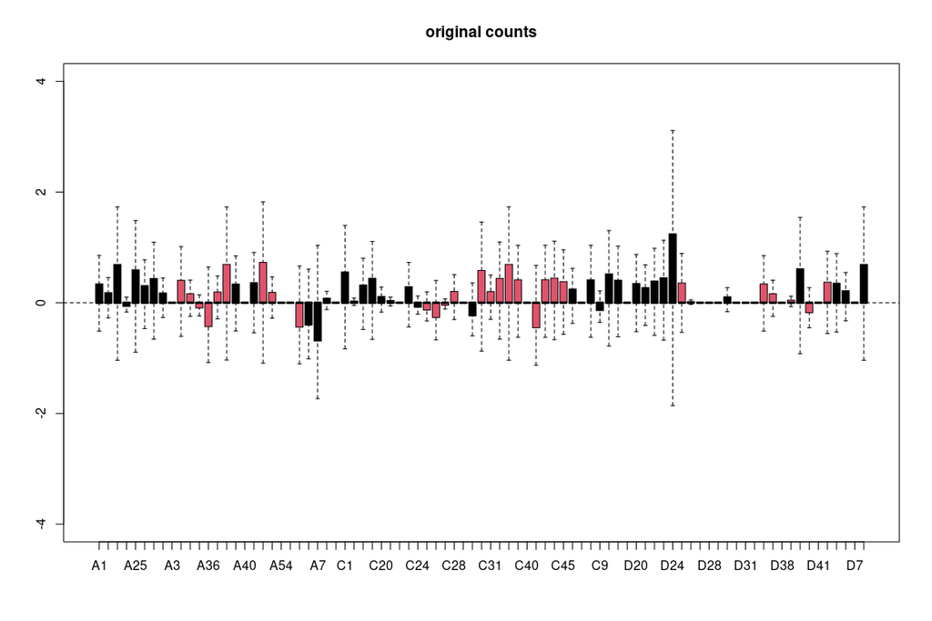

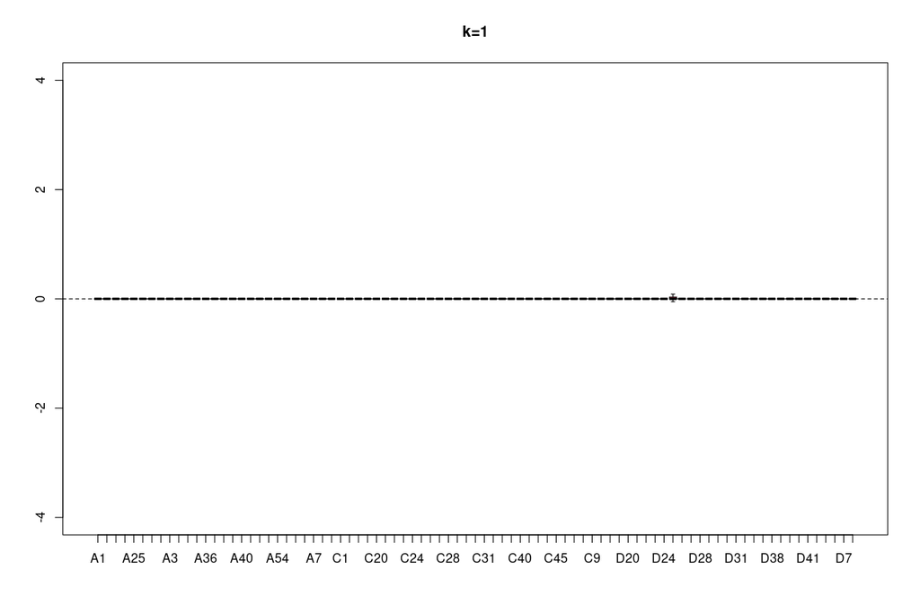

[1 more figures not shown]

From k = 3 batch effect starts to be minimal –> **I will use the first 3 factors of unwanted variation in DE analysis (DE_analysis.Rmd)**.

I plot the PCA of DESeq2-normalized and log2 transformed data computed as above BUT starting with RUVs adjusted raw counts with k = 3.

### 4.3.2 RUVs effect on PCA of DESeq2-normalized and log2 transformed data

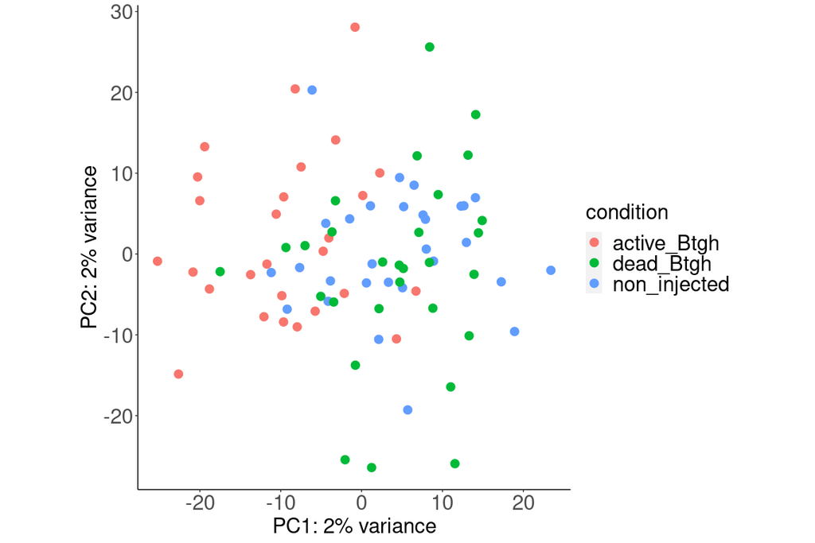

Some trend based on condition appear in PC1vsPC2 plot, but the variance associated with the PC is very low.

# 5 Data clustering using list of EGA and mat genes and including Conine 2c data

First of all, I make the DESeq DataSet including both ours and Conine’s data. I start from the raw counts for both datasets i.e. before any RUVs adjustment. Then I run the DESeq2 function for the merged raw counts’ table.

## 5.1 heatmap, including Conine data

To build the heatmaps below, I do the following:

1. I start from the DESeq Dataset including ours and Conine’s data, already DESeq2-normalized
2. I perform log2 transformation
3. I select only genes being strictly maternal/strictly EGA
4. I filter out genes whose rowMean is < 10
5. I build the heatmap, scaled by rows, with both genes and samples clustered by correlation.

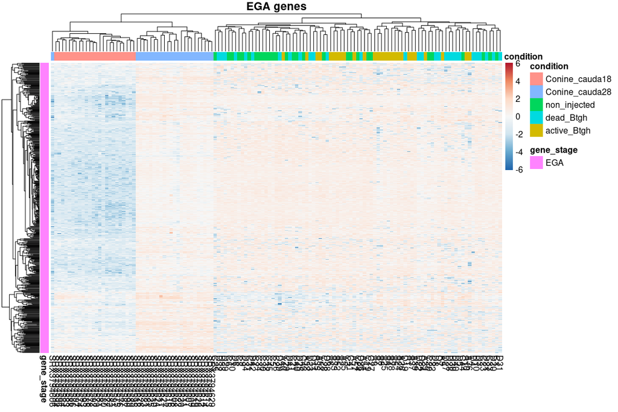

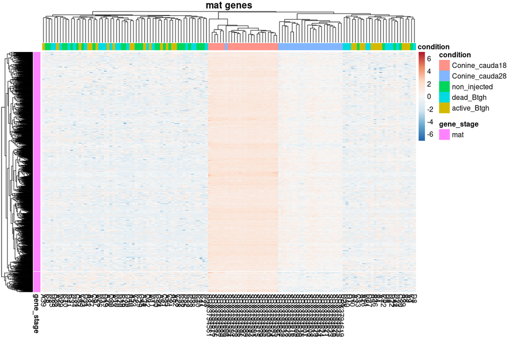

Conclusions:

- our data cluster with post-EGA 2c from the Conine dataset
- for both EGA and maternal genes, there is no additional clustering among the three experimental groups.

## 5.2 PCA

For this PCA, I select the first N genes showing highest variance in the Conine table, using cumulatives plot below to decide the N:

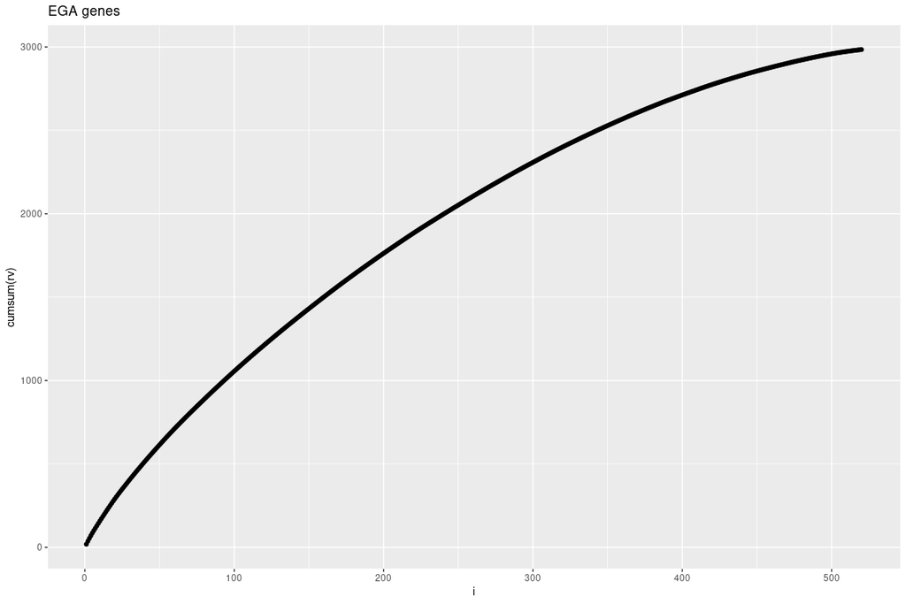

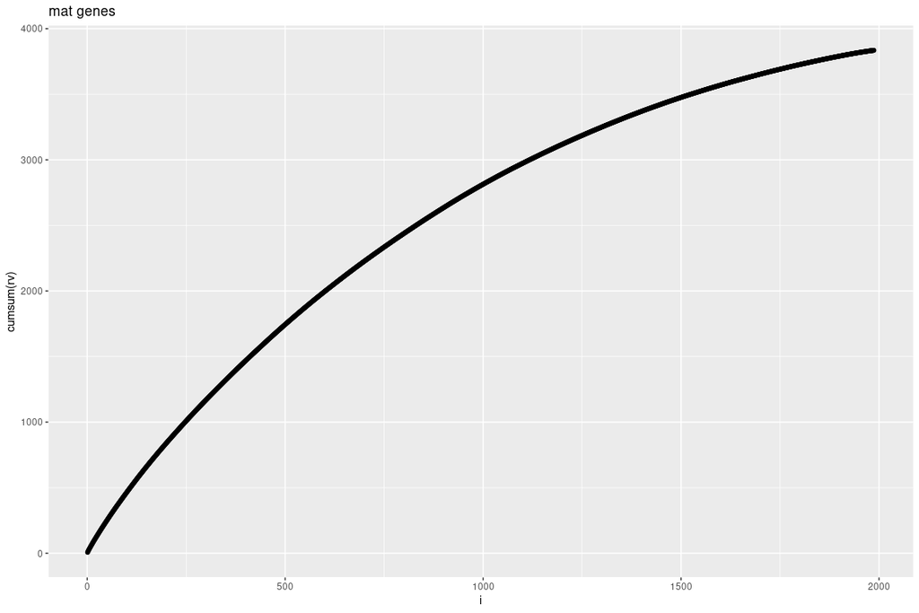

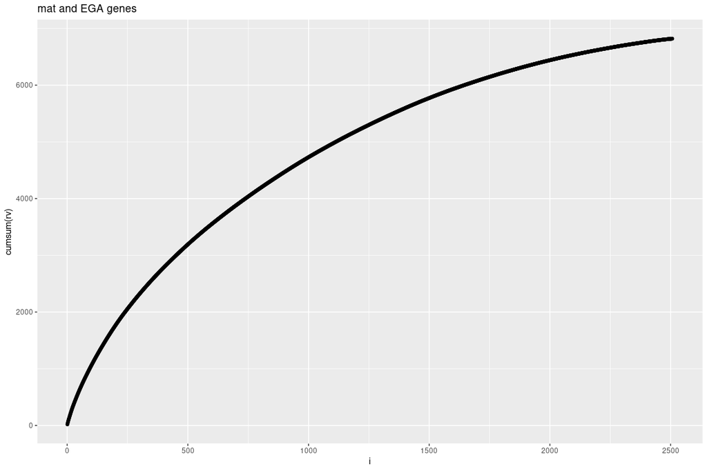

I choose:

- the first 500 strictly EGA genes
- the first 500 strictly mat genes
- the first 200 genes when pooling both

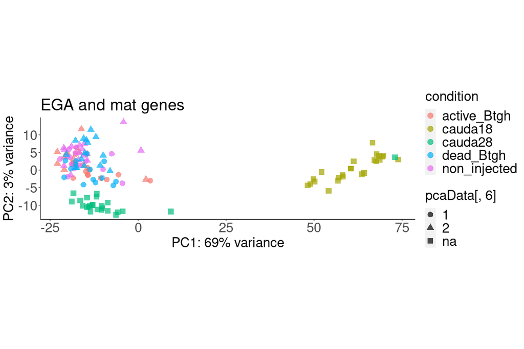